# Lab 1

Teslenko Denis, RI-440005

## Задание 1

1. Сгенерируйте 200 случайных значений из стандартного экспоненциального распределения и сохраните в вектор *exp.1*. Найдите среднее и стандартное отклонение из данных этого вектора.

```r
exp.1 = rexp(n=200)
mean(exp.1)
```

```
## [1] 1.116614
```

```r
sd(exp.1)
```

```
## [1] 1.04152
```

2. Повторите, использовав следующие значения параметра λ: 0.1, 0.5, 5, 10, и сохраните результаты в векторы: *exp.0.1*, *exp.0.5*, *exp.5*, *exp.10*.

```r
exp.0.1 = rexp(n=200, rate=0.1)
exp.0.5 = rexp(n=200, rate=0.5)
exp.5 = rexp(n=200, rate=5)
exp.10 = rexp(n=200, rate=10)
```

```r
mean(exp.0.1)
```

```
## [1] 10.25073
```

```r
sd(exp.0.1)
```

```
## [1] 10.49869
```

```r
mean(exp.0.5)
```

```
## [1] 2.173758
```

```r
sd(exp.0.5)
```

```
## [1] 2.275774
```

```r
mean(exp.5)
```

```
## [1] 0.1819511
```

```r
sd(exp.5)
```

```
## [1] 0.1828613
```

```r
mean(exp.10)
```

```
## [1] 0.09719969
```

```r
sd(exp.10)
```

```
## [1] 0.09995837
```

3. Функция `plot()` общая функция для визуализации данных. Функция `hist()` принимает данные и раскладывает их по корзинам. Чтобы использовать эти функции нужно для начала передать им данные, которые хотим визуализировать.
- Используйте функцию `hist()` для построения гистограммы полученного ранее стандартного распределения.

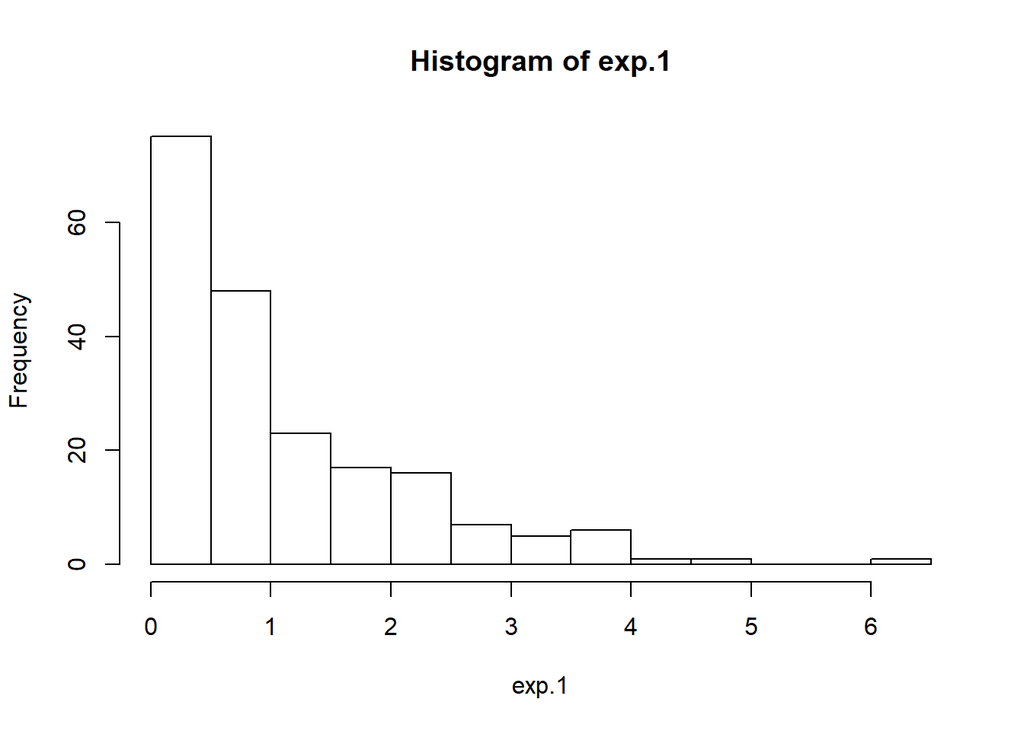

```r
hist(exp.1)
```

- Используйте функцию `plot()` с тем же самым вектором для построения графика значений в порядке следования.

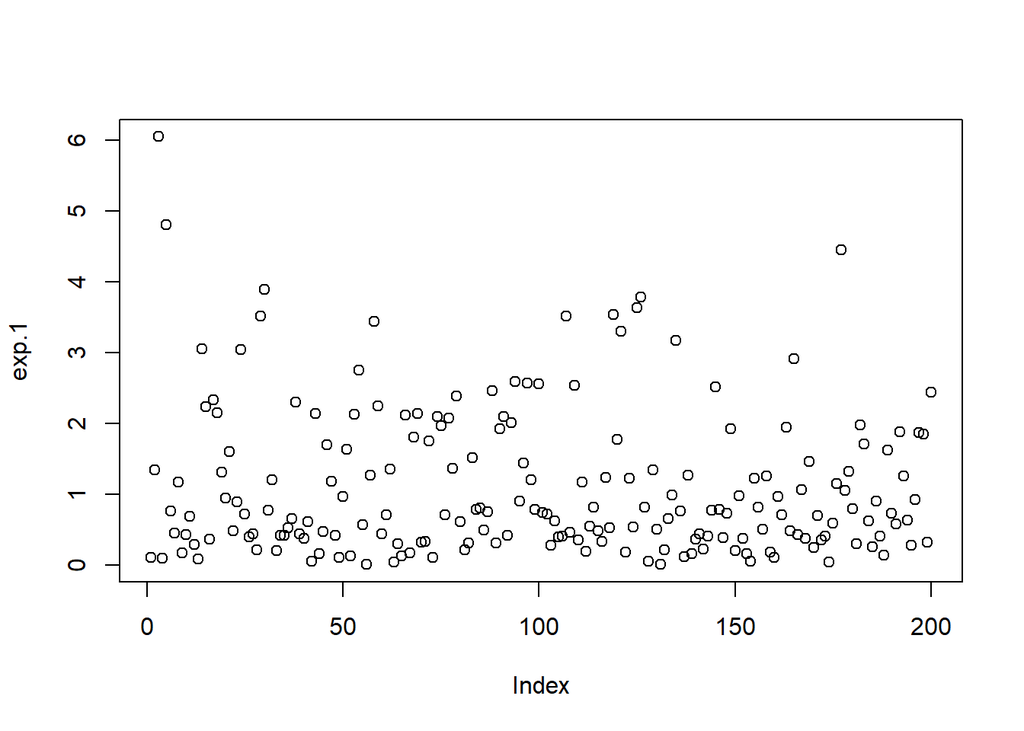

```r
plot(exp.1)
```

- Используйте функцию `plot()` с любыми двумя полученными ранее векторами, чтобы получить диаграмму рассеяния ([scatterplot](https://www.mathsisfun.com/data/scatter-xy-plots.html)) этих векторов относительно друг друга.

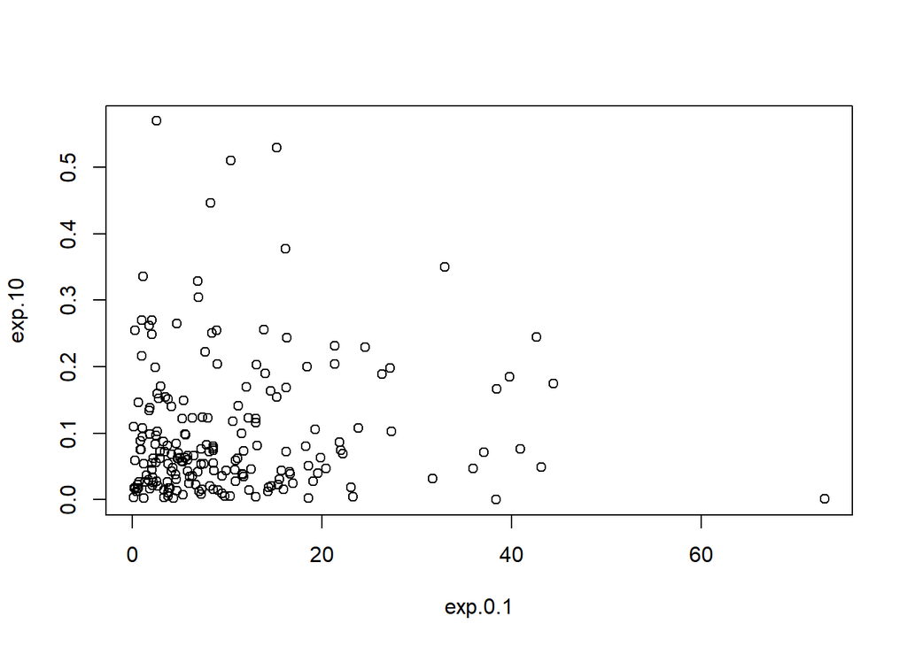

```r
plot(exp.0.1, exp.10)
```

4. Теперь сравним свойства всех наших векторов. Для начала создадим вектор, содержащий средние значения каждого из 5 полученных ранее распределений в порядке их создания. Полученный вектор сохраним в переменную *exp.means*.

```r
exp.means = c(mean(exp.1), mean(exp.0.1), mean(exp.0.5), mean(exp.5), mean(exp.10))
exp.params = c(1, 0.1, 0.5, 5, 10)
exp.sd_vect = c(sd(exp.1), sd(exp.0.1), sd(exp.0.5), sd(exp.5), sd(exp.10))
```

Далее необходимо создать следующие диаграммы рассеяния:

- Вектор с пятью средними относительно каждого из пяти векторов с различными значениями λ.

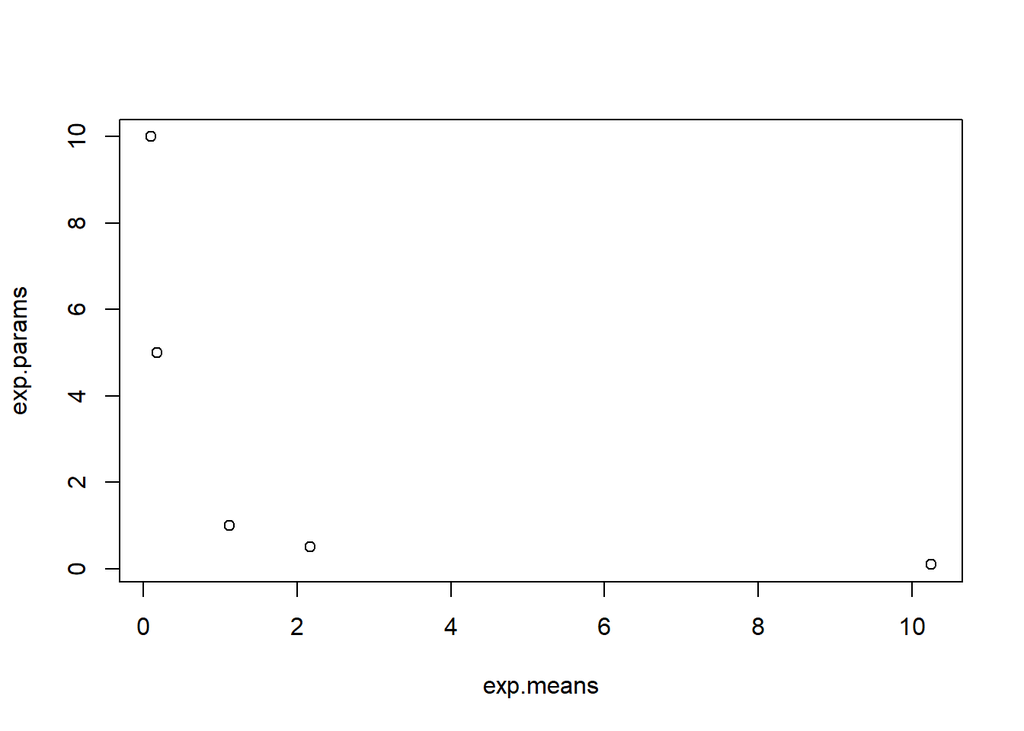

```r
plot(exp.means, exp.params)
```

- Вектор с пятью стандартными отклонениями относительно каждого из пяти векторов с различными значениями λ.

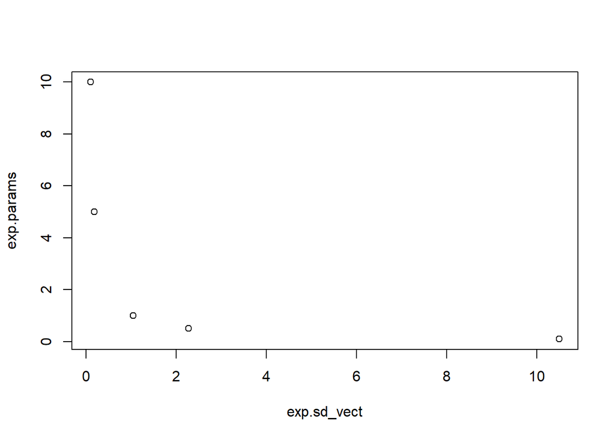

```r
plot(exp.sd_vect, exp.params)
```

- Вектор с пятью средними относительно вектора с пятью стандартными отклонениями.

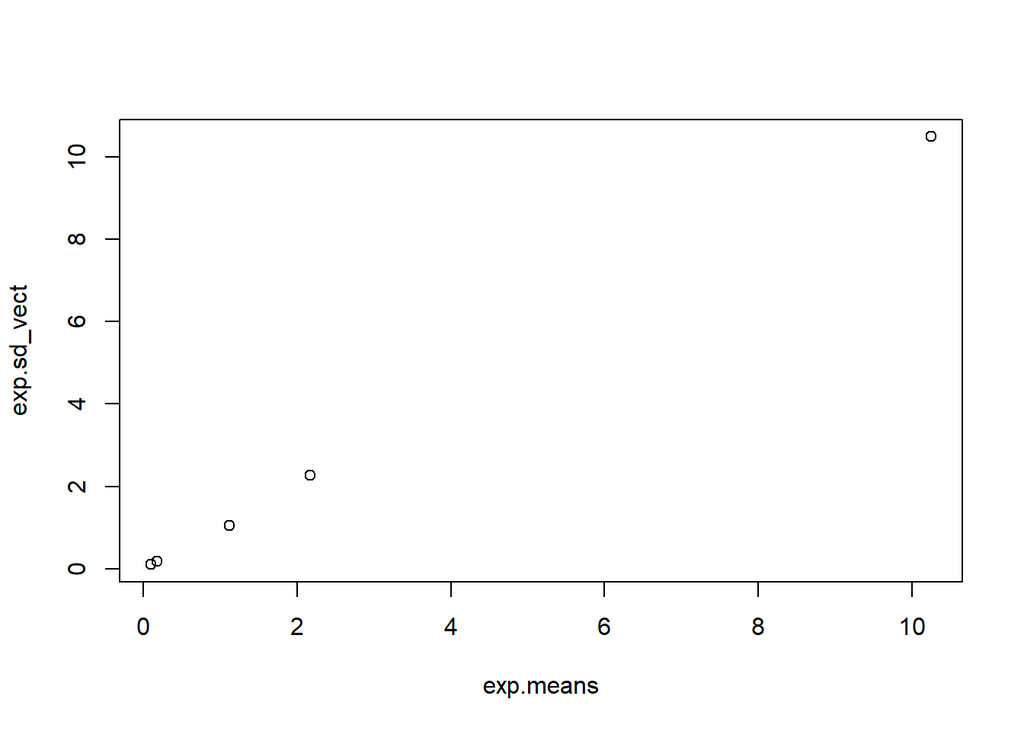

```r
plot(exp.means, exp.sd_vect)
```

**Выводы**

- Значения λ обратно пропорциональны mean и sd экспоненциального распределения и на графике представляют собой экспоненту
- sd и mean имеют прямолинейную зависимость

## Задание 2

R достаточно производителен, чтобы вычислять относительно большие объёмы данных.

- Для демонстрации сгенерируйте 1100000 (1 млн. 100 тысяч) чисел из стандартного экспоненциального распределения и сохраните их в вектор *huge.exp.1*. Получите среднее и стандартное отклонение.

```r
huge.exp.1 = rexp(n=1100000)
huge.exp.1.mean = mean(huge.exp.1)
huge.exp.1.sd = sd(huge.exp.1)
print(huge.exp.1.mean)
```

```
## [1] 1.000454
```

```r
print(huge.exp.1.sd)
```

```
## [1] 1.000358
```

- Получите гистограмму *huge.exp.1*. Она соответствует функции `1 - e:^(-x)`? Должна ли?

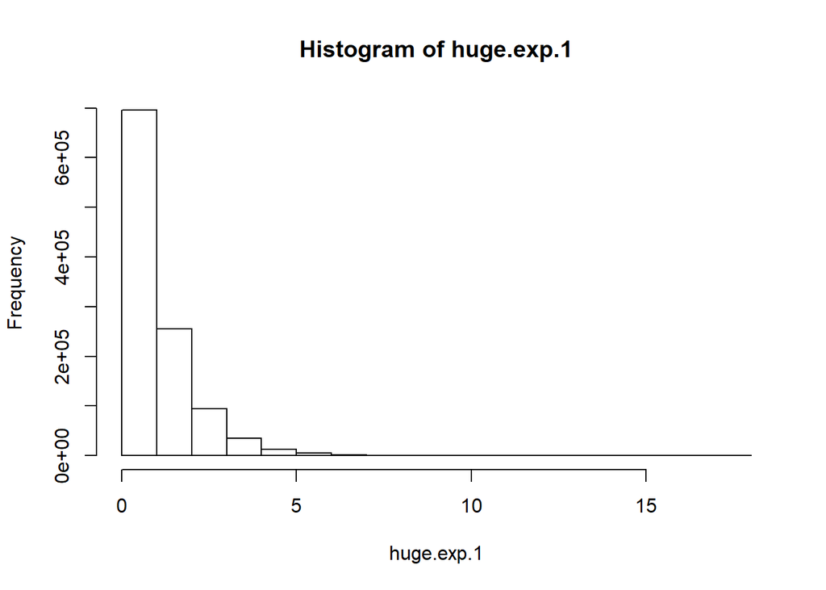

```r
hist(huge.exp.1)
```

*Полученный график распределения случайной величины очевидно не соответствует графику соответствующей функции распределения и не должен, т.к. в 1 случае - распределение случайной величины по экспоненциальному закону, а во втором - функция*

- Получите среднее всех чисел из *huge.exp.1* строго больших 1. Для проверки выборки может потребоваться новый вектор.

```r
mean(huge.exp.1[huge.exp.1 > 1])
```

```
## [1] 2.000307
```

- Получите матрицу *huge.exp.1.mat*, содержащую 1100 строк и 1000 колонок. Постройте гистограмму, использовав полученную матрицу. Что можно сказать о полученных данных?

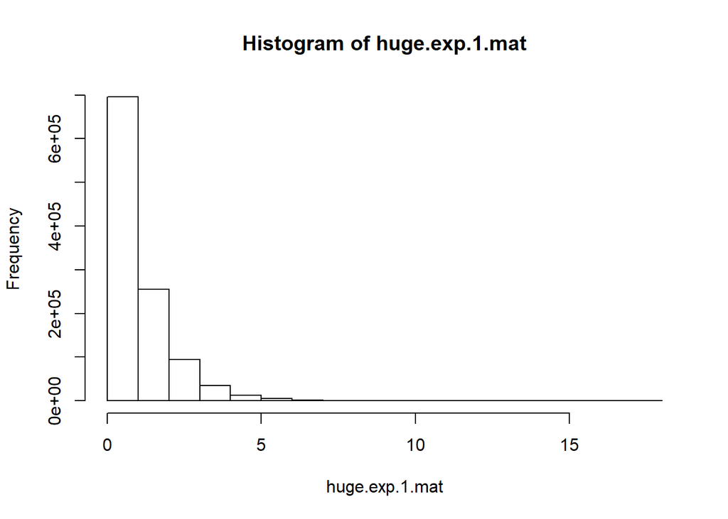

```r
huge.exp.1.mat = matrix(huge.exp.1, nrow=1100, ncol=1000)
hist(huge.exp.1.mat)
```

- Рассчитайте среднее 137-й колонки из *huge.exp.1.mat*.

```r
mean(huge.exp.1.mat[ , 137])
```

```
## [1] 0.9996388
```

- Найдите среднее всей 1000 колонок и сохраните их в вектор. Отобразите диаграмму средних значений колонок. Объясните почему форма диаграммы отличается от виденных ранее.

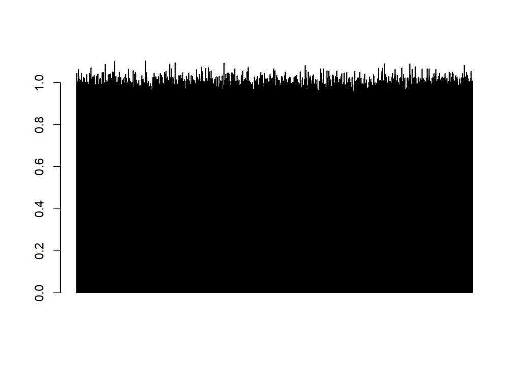

```r
huge.exp.1.mat.mean = colMeans(huge.exp.1.mat)
barplot(huge.exp.1.mat.mean)
```

*Форма отличается, т.к. мы имеем дело с другими данными.*

- Рассчитайте квадрат каждого значения из *huge.exp.1* и найдите среднее и стандартное отклонение полученного вектора квадратов. Объясните отличие от соответствующих показателей вектора *huge.exp.1*. Вам может помочь формула, по которой R рассчитывает стандартное отклонение: `sqrt(sum((x - mean(x))^2) / (n - 1))`.

```r
huge.exp.1.square = huge.exp.1 ^ 2
huge.exp.1.square.mean = mean(huge.exp.1.square)
huge.exp.1.square.sd = sd(huge.exp.1.square)
print(huge.exp.1.square.mean)
```

```
## [1] 2.001624
```

```r
print(huge.exp.1.square.sd)
```

```
## [1] 4.484923
```

С увеличением значения x увеличивается значение mean и sd. Стоит отметить, что стандартное отклонение растет быстрее.